# Global Trends In Urban Energy Use

Elliot Cohen, Vijay Modi, Henri Torbey, Yu Tian and Michael Piccirilli

January 14 2015

## Motivation

Many of the world’s **largest** and **fastest-growing** cities–from Karachi (pop. 14 million; 34.6% increase from 2000-2010) to Delhi (22m; 39.4%), Dhaka (15m, 45.2%), Jakarta (10m; 14.8%), Bangkok (8m, 29.1%), Lagos (11m; 48.2%) and Kinshasa (9m, 55.4%)–are located in South Asia and Sub-Saharan Africa with tropical to sub-tropical climates unlike those of most OECD member cities in the global North. As the tropics/sub-tropics become increasingly urban, inudstrial and affluent, it is important to consider how energy demand–particularly for thermal comfort–will evolve differently in these places than it has historically across the OECD.

To illustrate the potential for vast differences in energy demand for thermal comfort between cities in the global North and cities in the Tropics/Sub-Tropics, consider Delhi, India. Delhi–with its massive population and very hot climate–is an outlier compared to OECD member cities but typical of South Asia: Peak summer temperatures routinely exceed 40 deg C. (104 F.), and intense heatwaves can approach 50 deg C. (122 F.). Given the huge temperature differential between outdoor (say 104 F.) and desired indoor air temperature (say 72 F), and the thermodynamic fact that energy for cooling scales linearly with the temperature differential, cooling a room in Delhi requires twice as much energy as cooling a room in New York where the summer outdoor-indoor temperature differential is typically half that.

In addition to higher temperatures, the summer season is also much longer: in the past year, Delhi had over **six** times as many cooling-degree days as New York City (again assuming a desired indoor air temperature of 72 deg F). Compounded by leaky building envelopes in developing world cities (designed for natural ventilation, not air conditiong), intense heat-island effects (typically less green space), and massive population growth, peak electricity demand in cities thourought the developing world could one day surpass that of their neighbors to the north–not only in aggregate terms because of their population, but also *per-capita* due to climate, building design and thermodynamics.

## Implications of Global Energy Service Provision Parity

If we consider the trajectory of developing world cities as reaching eventual parity with OECD cities, and if we think in terms of energy *service provision* rather than just BTU or KWh, then we begin to appreciate the magnitude of future energy demand (and associated resource consumption and environmental impact). This has important implications not only for regional grid planning and supply reliability, but also the global transition to renewable energy given the limitations of meeting such large and ‘peaky’ demand with non-dispatchable resources such as wind and solar.

Figure 1 provides a map of urbanization rates for cities worldwide with a population greater than 750,000 (UN 2011). Urbanization rates are clearly highest in South Asia and Sub-Saharan Africa. Figure 2 shows the *distribution* of population growth rates for the same set of cities, grouped by latitude (global North, Tropics and Subtropics). The expected value (e.g. central tendancy) of urbanization rates in the Tropics and Sub-Tropics is clearly distinct from that of the North.

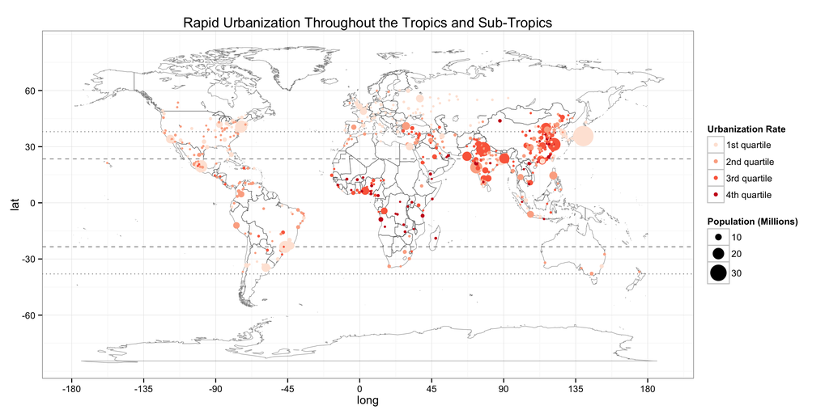

| Continent | Country | Urban.Agglomeration | Population [MM] |
| --- | --- | --- | --- |
| Asia | Japan | Tokyo | 38.19668 |
| Asia | India | Delhi | 25.62895 |
| Asia | China | Shanghai | 22.96283 |
| North.America | Mexico | Ciudad de México (Mexico City) | 21.70558 |
| North.America | U.S.A | New York-Newark | 21.32630 |
| Asia | India | Mumbai (Bombay) | 21.21378 |
| South.America | Brazil | São Paulo | 21.02837 |
| Asia | China | Beijing | 18.07926 |
| Asia | Bangladesh | Dhaka | 17.38202 |
| Asia | Pakistan | Karachi | 15.50043 |
| Asia | India | Kolkata (Calcutta) | 15.07639 |
| South.America | Argentina | Buenos Aires | 14.15065 |
| North.America | U.S.A | Los Angeles-Long Beach-Santa Ana | 14.08080 |
| Africa | Nigeria | Lagos | 13.12087 |
| Asia | Philippines | Manila | 12.85567 |
| Asia | Turkey | Istanbul | 12.45941 |
| Europe | Turkey | Istanbul | 12.45941 |
| Asia | China | Guangzhou, Guangdong | 12.38508 |
| South.America | Brazil | Rio de Janeiro | 12.38035 |
| Asia | China | Shenzhen | 12.33708 |

| Continent | Country | Urban.Agglomeration | Growth.Rate [%] |
| --- | --- | --- | --- |
| Asia | Thailand | Samut Prakan | 9.147428 |
| Asia | Viet Nam | Can Tho | 8.780760 |
| Africa | Somalia | Muqdisho (Mogadishu) | 8.011903 |
| Africa | Côte d’Ivoire | Yamoussoukro | 7.519953 |
| Asia | U.A.E | Abu Zaby (Abu Dhabi) | 7.215404 |
| Africa | Burkina Faso | Ouagadougou | 6.878042 |
| Asia | Indonesia | Batam | 6.784434 |
| Asia | U.A.E | Dubayy (Dubai) | 6.749912 |
| Asia | U.A.E | Sharjah | 6.505458 |
| Asia | China | Xiamen | 5.932819 |
| Asia | China | Suzhou, Jiangsu | 5.920969 |
| Africa | Niger | Niamey | 5.861409 |
| Asia | China | Wuhu, Anhui | 5.811846 |
| Asia | China | Hefei | 5.783493 |
| Asia | China | Yinchuan | 5.773824 |
| Asia | Indonesia | Denpasar | 5.738102 |
| Africa | Nigeria | Abuja | 5.737928 |
| Asia | China | Jinjiang | 5.634350 |
| Asia | China | Zhongshan | 5.583367 |
| Asia | India | Tiruppur | 5.344795 |

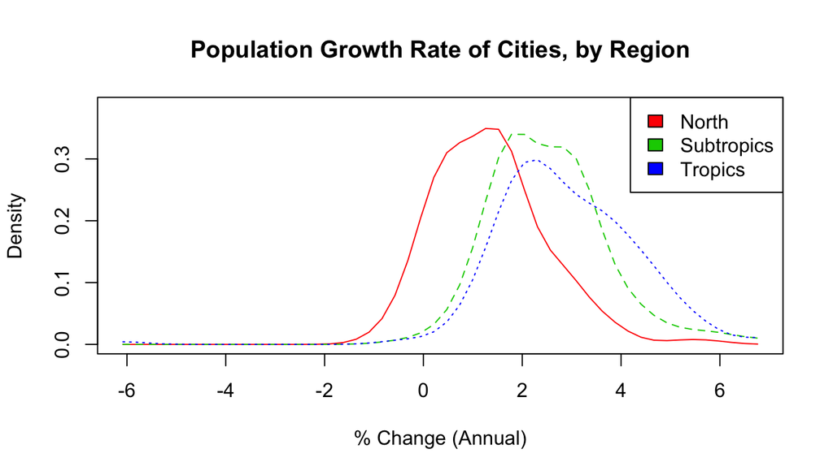

## Rationale

Mid- to long-range global energy demand forecasts are typically reported as annual totals and provide little insight to the temporal distribution throughout the year. To address this shortcoming, we focus on the diurnal and seasonal distribution of energy demand and supply, which drive system cost but recieve relatively little attention in global energy outlooks. This requires more and better data than is typically available to researchers.

## Methods and Materials: A Global Survey

This study presents an empirical analysis of diurnal-to-seasonal energy use patterns for 39 global cities.

### Load data collection

High resolution hourly load data for the past 3 years for cities in the Tropics/Sub-Tropics and North was collected from utility companies and electricity regulatory bodies.

In the global North, data was obtained for the following 21 US cities from the Federal Energy Regulatory Commission (FERC) and the Energy Information Administration (EIA) for the years 2007-2013:

- Chattanooga
- City of Independence
- City of North Little Rock
- Colorado Springs
- Detroit
- El Paso
- Eugene
- Honolulu
- Indianapolis
- Kansas City
- Los Angeles
- Louisville
- Memphis
- Omaha
- Sacramento
- San Diego
- Seattle
- Springfield
- Tacoma
- Tampa
- Tucson.
- New York City’s hourly load profile was obtained for the years 2007, 2008, 2009, 2010, 2011 and 2012 from the Sustainable Engineering Lab.
- Philadelphia’s hourly load profile was collected for the years 2009, 2010 and 2011 from the utility Philadelphia Electricity Company’s website.

In the Tropics and Sub-Tropics, hourly demand data was collected for the following cities and from the following sources:

- Abidjan, Cote D’Ivoire: Hourly data for the years 2010, 2011, 2012 and 2013 were collected from Cote D’Ivoire’s electricity regulatory body, ANARE (Autorite Nationale De Regulation du Secteur D’Electricite).
- Accra and Tema, Ghana: Hourly data for the years 2013 and 2014 were collected from Ghana’s utility company Ghana Grid Company Ltd.
- Antigua, Antigua and Barbuda: Half-hourly data for the year 2011 was obtained from the Sustainable Engineering Lab, Columbia University.
- Dakar, Senegal: Hourly data for the years 2010, 2010, 2012 and 2013 are being collected from Senegal’s utility company, Senelec.
- Delhi and Chandigarh, India: Hourly data for years 2012 and 2013 (Delhi) and for years 2011, 2012 and 2013 (Chandigarh) were obtained from the Sustainable Engineering Lab.
- Kano, Nigeria: Daily peak load was obtained for the year 2014 from the Sustainable Engineering Lab, Columbia University.
- Kupang, Indonesia: Hourly data for the year 2014 was obtained from the Sustainable Engineering Lab, Columbia University.
- Mbabane, Swaziland: Hourly data for the year 2012, 2013 and 2014 were obtained from Swaziland’s utility company, Swaziland Electricity Company.
- Metro Manila, Philippine: Hourly data for the years 2011, 2012 and 2013 are being collected from the the Philippine Electricity Market Corporation.
- Nairobi, Kenya: Hourly data for the years 2011, 2012 and 2013 were collected from Kenya’s utility company, Kenya Power.
- Singapore: Half-hourly data for the year 2013 were collected from Singapore’s market operator Energy Market Authority’s website.
- New South Wales, Queensland, South Australia and Victoria, Australia: Hourly data for the years 2000, 2001, 2002, 2003, 2004, 2005 and 2006 were obtained from: Thatcher, (2007) Modelling Changes to Electricity Demand Load Duration Curves as a Consequency of Predicted Climate Change for Australia, Elsevier Energy.
- Tokyo, Japan: Hourly data for the years 2008 to 2014 were collected from Tokyo’s utility company, Tokyo Electric Power Company.

## Methods

Two main analyses are performed in this study. The first one consists in deriving the peak electricity demand climate sensitivity (cooling coefficient) and threshold temperature for every city, and the second consists in mapping this sensitivity measure of cities to socio-economic factors.

For either case, the flow chart of operations is more or less the same.

Because there is usually no economic and commercial activities in the weekends compared to weekdays, demand for electricity is expected to be lower on weekends. To avoide this noise in the analyses, corresponding observations are disregarded.

Starting with the temperature and load profile of a city, the temperature-load profile can be obtained by making correspond the load to the matching temperature. Plotting the load against the temperature, one obtains the temperature-load curve. Depending on the city, this profile can either be in the form of a “V” shape, or of a “cloud” shape.

The below leftward figure is a clear “V” shape temperature-load curve for New York City. The right side of the curve represents the cooling regime: as temperatures increase, demand for electricity increases because of cooling requirements. The cooling regime, and therefore the city’s sensitivity to high temperatures, is characterized by a positive coefficient called the cooling coefficient. The left side of the curve represents the heating regime; as temperatures decrease, demand for electricity increases because of heating requirements (although the main heating requirements are not power by electricity but natural gas, some heating appliances do use electricity). The city’s sensitivity to cold temperatures is characterized by a negative coefficient called the heating coefficient, which tend to be lower in absolute terms compared to cooling coefficient.

In constrast, the below rightward figure is a clear “cloud” shape temperature-load curve for Accra. This shape indicates that the city is only in the cooling regime as temperatures are always high.

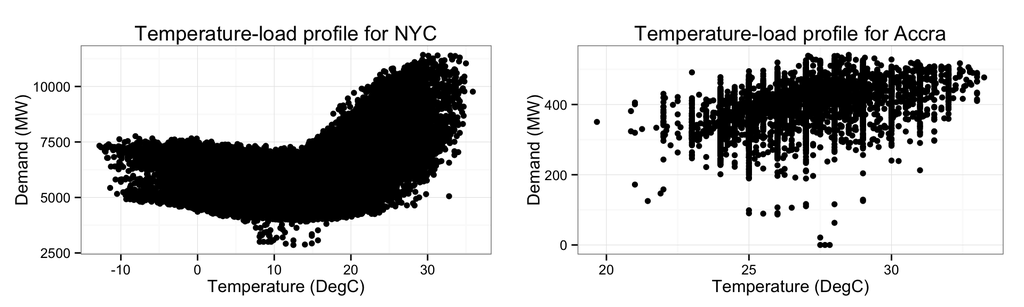

The above correleations being made for observations at all hours of the day, subsetting them by daily peak load would give the “maximum” temperature-load relation for every city.

The above procedure was applied for absolute load values.

To ensure comparability between cities of different sizes (i.e. putting the load on the same scale), the same procedure is repeated for the scaled load for every city at every hour. Isolating the data by city and hour of day, scaling the load consists in subtracting the average of load to the observed load and dividing by the standard deviation, as per the following formula:

$\textrm{Scaled load} = \frac{\textrm{Observed load - Average of observed loads}}{\textrm{Standard Deviation of observed loads}}$

The scaled coefficients are therefore obtained.

## Results

Having derived the overall and scaled maximum cooling coefficients for all the cities, this section consists in visualizing them to define some trends under which cities can be characterized.

### Scaled cooling coefficients

Deriving a scatterplot of scaled peak cooling coefficient and latitude for every city, a general trend can be noticed:

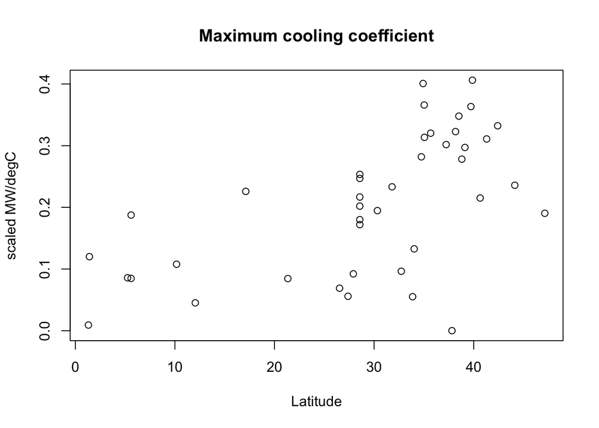

As cities get away from the Equator, the sensitivity of their peak electricty demand to temperature increases.

Deriving a scatterplot of Threshold Tempertature and latitude for every city, a general trend can also be noticed:

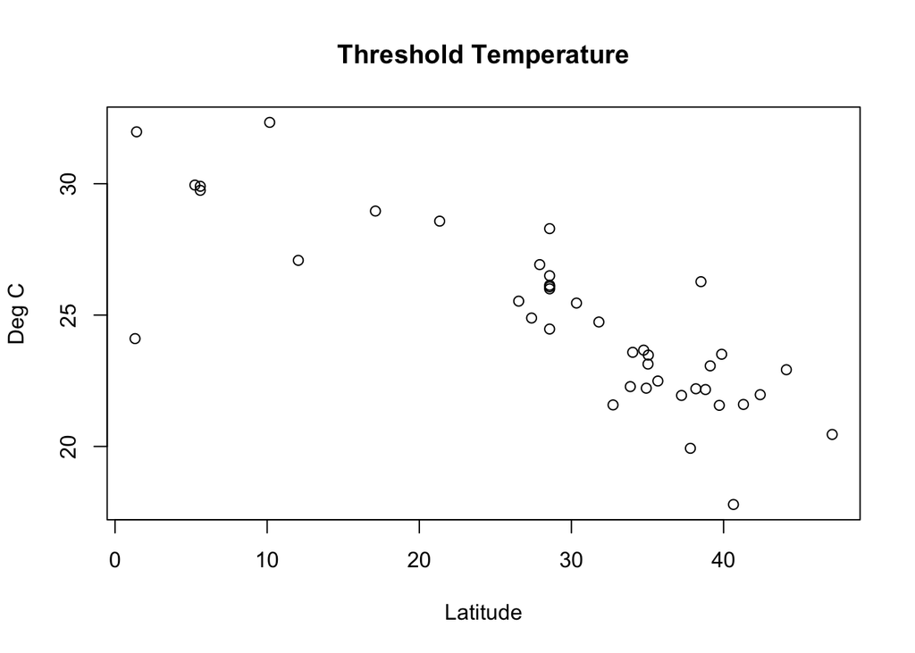

As cities get away from the Equator, the temperature at which cooling requirement start kicking-in (Threshold Tempertature) decreases.

### Mapping the temperature sensitivity of cities with respect to socio-economic factors

Using absolute (unscaled) cooling coefficients derived earlier in the study, the city peak electricity demand sensitivity to high temperatures can be related to socio-economic factors (population and GDP per Capita).

The overall coefficients (MW/DegC) for every city is printed below: Cities that only have a cooling regime have “0” as heating coefficient:

| cities | lattitude | intercept | heating | cooling | threshold.t |
| --- | --- | --- | --- | --- | --- |
| Abidjan | 5.2500 | 422.07130 | 0.000000 | 3.3223402 | 29.95033 |
| Accra | 5.6025 | 117.90922 | 0.000000 | 11.3731741 | 29.90393 |
| Antigua | 17.1170 | 15.09864 | 0.000000 | 1.0677315 | 28.96077 |
| Chandigarh | 30.3330 | 293.71004 | -3.684036 | 10.9991375 | 25.42598 |
| Chattanooga | 35.0330 | 1036.56894 | -18.150468 | 59.5385413 | 23.25115 |
| City of North Little Rock | 34.7470 | 129.55579 | -1.037714 | 10.9810987 | 23.79348 |
| Colorado Springs | 38.8120 | 681.62264 | -4.811857 | 25.1837667 | 22.51618 |
| Delhi | 28.5670 | 4033.65924 | -38.830487 | 150.9773290 | 25.88045 |
| Delhi - BRPL | 28.5670 | 1883.91062 | -25.905176 | 75.3459026 | 25.84230 |
| Delhi - BYPL | 28.5670 | 960.84335 | -9.692203 | 34.3655181 | 25.44420 |
| Delhi - MES | 28.5670 | 67.27419 | -1.355209 | 1.9318003 | 28.38946 |
| Delhi - NDMC | 28.5670 | 267.16431 | -4.175421 | 13.7383321 | 24.40597 |
| Delhi - NDPL | 28.5670 | 1210.88333 | -12.654506 | 38.4937854 | 26.01223 |
| Detroit | 42.4090 | 7364.95291 | -27.305855 | 425.7051534 | 22.42340 |
| El Paso | 31.8055 | 1060.15180 | -5.634925 | 52.5280352 | 24.88626 |
| Eugene | 44.1290 | 484.12354 | -8.753498 | 13.7137710 | 22.62144 |
| Honolulu | 21.3390 | 654.78029 | 0.000000 | 15.9173765 | 28.57617 |
| Indianapolis | 39.7215 | 2331.42079 | -29.211187 | 130.1447217 | 21.61598 |
| Kano | 12.0480 | 133.27971 | 0.000000 | 1.7470750 | 27.08390 |
| Kansas City | 39.1230 | 335.90544 | -2.406482 | 16.4593361 | 23.54341 |
| Kupang | -10.1670 | 18.75284 | 0.000000 | 1.1746676 | 32.33636 |
| Los Angeles | 34.0280 | 1820.16243 | 0.000000 | 87.9978174 | 23.58382 |
| Louisville | 38.1800 | 5507.25634 | -69.514955 | 289.3428633 | 22.53161 |
| Mbabane | -26.5330 | 22.41759 | 0.000000 | -0.2288207 | 25.53149 |
| Memphis | 35.0555 | 1920.05995 | -15.882500 | 147.5119036 | 23.73495 |
| Nairobi | -1.3170 | 607.69473 | 0.000000 | 0.2708732 | 24.10480 |
| New South Wales | -33.8700 | 11517.44069 | 0.000000 | -67.5009074 | 22.27814 |
| New York City | 40.6500 | 7194.93712 | -40.886995 | 287.8771710 | 17.77754 |
| Omaha | 41.3050 | 1441.45539 | -11.633088 | 85.4358090 | 21.93360 |
| Philadelphia | 39.8755 | 2719.82634 | -51.103801 | 238.3251382 | 23.70966 |
| Queensland | -27.3800 | 5121.32623 | 0.000000 | 49.4491395 | 24.88929 |
| Sacramento | 38.5130 | 1836.58643 | -23.021574 | 104.3846181 | 23.03922 |
| San Diego | 32.7350 | 2100.01924 | 0.000000 | 42.7534016 | 21.58114 |
| Singapore | 1.4170 | 3680.98911 | 0.000000 | 82.9584796 | 31.97710 |
| South Australia | -34.9200 | 2658.95881 | -51.324019 | 107.2355247 | 22.37295 |
| Springfield | 37.2365 | 440.82972 | -3.862176 | 30.6025041 | 22.56469 |
| Tacoma | 47.1420 | 944.10026 | -19.451794 | 22.8702281 | 20.39689 |
| Tampa | 27.9160 | 1510.85691 | 0.000000 | 51.8598843 | 26.92180 |
| Tema | 5.6025 | 118.55827 | 0.000000 | 2.0087191 | 29.75004 |
| Tokyo | 35.6830 | 51666.68082 | -739.793354 | 2096.1023747 | 22.74764 |
| Victoria | -37.8200 | 6491.58417 | 0.000000 | 0.6702121 | 19.92956 |

Dividing the city-wide absolute cooling coefficients by the corresponding population size (for the year 2008 for consisteny with GDP data that is uniformly available for year 2008 - population size taken from the UN), and derving the GDP/Capita (for the year 2008) for the cities, the following plot can be obtained:

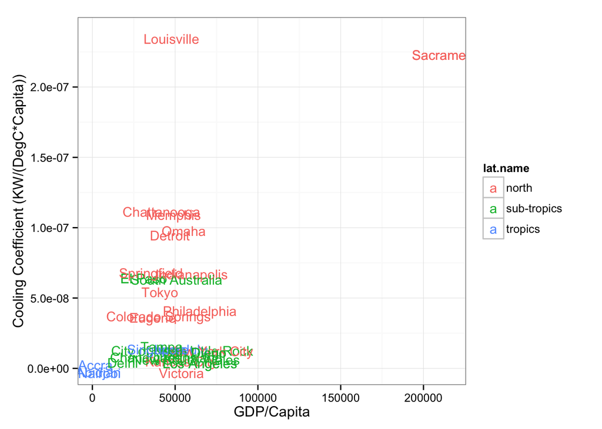

Northern cities exhibit a much higher cooling coefficient per capita than tropical and sub-tropica cities, and their amplitudes do not seem to be directly proportional to GDP/Capita of the city. A reason for that may be that above a certain threshold GDP/Capita, cooling is no longer income sensitive and depends on other factors.

Plotting the threshold temperature againt the GDP/Capita, and ignoring Sacramento and Tropical cities the below plot can be obtained:

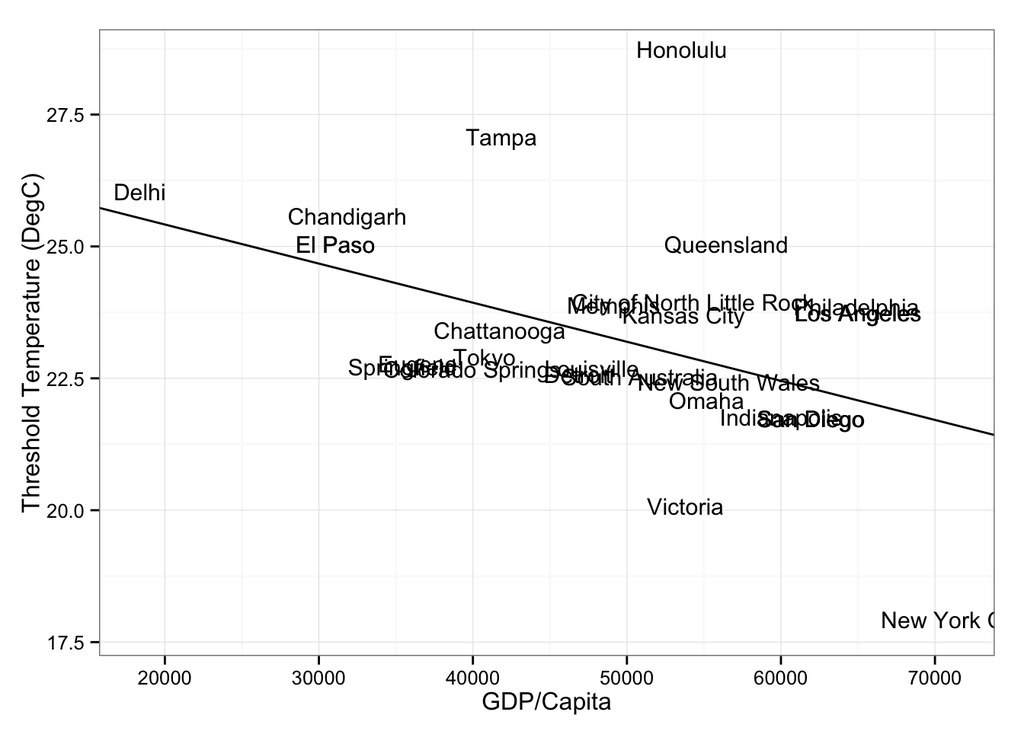

It can be seen from the above plot that as the GDP/Capita increase, the threshold temperature decreases.

## Literature Review

Predicting regional electricity demand and estimating daily peak load are essential issues in electricity market. They are important references for long-term investment decision-making, power generation projection, price making, and etc. Since daily peak load reflects the requirement on the supply capacity and annual total reflects the requirement on production scale, it gives important implication on such that desired installed capacity, therefore makes sure the production plan minimizes the waste and maximum the profits while meeting the requirement on supply.

## Climatic Perspective Predictions

Daily and seasonal variability in urban electricity demand is caused, to a large degree, by the usage of cooling and heating devices, which is most significantly affected by meteorological factors.

Segal et al. (1992) [1] evaluated, at regional level, the interrelationship between the summer peak energy consumption in Israel and pertinent meteorological parameters. This paper proposed a classic linear regression model between climate and electricity demand that is very often referred to in later literature. Crowley et al. (2003) [2] analyzed the role of climate change-driven effects on electricity demand in both residential and commercial sectors, which are considered to be most sensitive to temperature changes. The study predicted using actual temperature data an average demand increase of 3.8% in Pennsylvania, New Jersey and Maryland. Later Thatcher (2007) [3] built a demand predicting model base on Segal et al’s study, which uses only daily max/min temperature and relative humidity as input to estimate electricity demand. The author first took daily max/min temperature to estimate apparent temperature in 30-mins’ intervals using sine-exponential technique; then use the modified linear regression model between climate and demand to obtain the prediction of electricity demand. The model was also applied to estimate how Load Duration Curves (LDC) change as a result of a 1 degree increase in the average temperature in Australian state capital cities.

Even though researchers always choose to use different technique, apply the analysis to different regions, and have different focuses consider considering context features, there are essential concepts and mechanisms that are generalizable to any methodology in this area of research.

### CDD/HDD

Cooling degree days and heating degree days are measurements that reflect the amount of energy demand needed to cool or heat a building. The cooling/heating requirement at a specific location is considered to be proportional to its CDD/HDD.

${CDD} = \left \{ T_{ave} - T_{b}, 0 \right \} {HDD} = \left \{ T_{b} - T_{ave}, 0 \right \}$

### The temperature-electricity curve

[figure 1 omitted]

### Regression Model

Regression models between climatic factors and electricity demand can summarize the climatic influences on electricity demand, thus can be used for demand prediction. We reviewed two approaches for regression, one is Standard Seasonal Time Series Modeling Approach, the other is Multiple Regression Model.

## Socio-economic Perspective

Climatic approach is not sensitive enough to effectively response to climate independent factors, the most important one of which is socio-economic factors. Many different approaches dealing with this issue are found in literature, and can be categorized into macro-level approaches and micro-level approaches. Macroeconomic approach uses macro data at the country or sub-national/state level to estimate the income elasticity of electricity consumption. One example is Bose and Shukla’s (1999) [4] research. On the other hand, microeconomic approach uses micro-level data that reflects individual and household behavior to analyze across different heterogeneous household sub-groups. Examples are Tiwari (2000) [5], Pachauri (2004) [6], The World Bank (2008) [7].

## Predictions for tropic and sub-tropical cities

As tropical and sub-tropical cities become increasingly urban, industrialized and affluent, Pachauri and Spreng (2004) [8] found that urban households in India would change energy consumption patterns. They would consume more energy per capita and would move from less efficiency energy sources such as biomass and kerosene to more efficient energy sources such as electricity and LPG, therefore leading to an increase in peak electricity demand and consumption.

A seminal paper on the relation between climate, electricity demand and prediction model was made by Segal et al. (1992) [1]. The author studied the correlation between peak electricity load and meteorological parameters (temperature, humidity and wind speeds) and proposed a regression model modeling this relation. Subsequently, Thatcher (2007) [3], based on Segal Et Al.’s model, derived an effective electricity demand model that uses time (data and specific time) and relative temperatures as inputs and that outputs fairly accurate forecasted demand at 30 minutes resolution. These 2 studies, however, provide detailed modeling for a particular mature utility and are therefore hard to generalize to other locations (i.e. developing world region).

In terms of electricity demand sensitivity to climate in the developing regions, 2 studies by the same author (Gupta, Indian Statistical Institute, Delhi, India) were reviewed. The first one (2012) [9] adopted a semi-parametric coefficient model that allowed the temperature-electricity relation to vary over time for Delhi. Its main findings were that electricity demand is a U-shaped function of temperature and that the cooling demand per unit increase in temperature is increasing over time. The second study by the same author (2014) [10] took into account 28 Indian states and did not constraint itself to only 1 city. From this study, Gupta found that the summer electricity demand sensitivity to temperature is higher in hotter climate Indian states and that similarly, winter electricity demand sensitivity to temperature is higher in colder Indian states. He hypothesized that, it was because in hotter climate states people used more energy units of cooling equipment, and similarly, in colder states people used more energy units of heating equipment. He also conjectured that the effect of both hotter and colder weather on electricity demand sensitivity would be more pronounced with higher incomes and GDP/Capita. This study takes Gupta’s 2014 paper (2014) [10] a step further by doing a global survey, including international emerging and developed cities from the US, West Africa, South Asia and South East Asia, and mapping their sensitivity properties by socio-economic and geographic factors.

## Data

In order to achieve the objective of our research, we looked for electricity demand data, weather data, GDP data, and population data for cities ranging all over the world, with more focus placed on largest and fastest growing cities in tropics and subtropics. We expect the number of cities that we have for demand, weather, GDP and population data corresponding to each other as many as possible.

## Weather Data

The National Oceanic and Atmospheric Administration (NOAA) offers a variety of free meteorological and climatological information through the National Climatic Data Center. The data is available on the Online Climate Data Directory website, available via FTP, which we can download and efficiently process in R. We chose the weather stations closest to our cities of interest, and eliminated the invalid data (missing values, 999s and NAs) to get the climatic information for each city of interest in terms of temperature, wind speed, wind direction, dew point temperature, and atmospheric pressure. The data and its source are summarized in Table 2.

| City | Country | Source | Description |
| --- | --- | --- | --- |
| Abidjan | Cote d’lvoire | NOAA | 2010-2014; hourly |
| Accra | Ghana | NOAA | 2010-2014; hourly |
| Antigua |  | NOAA | 2011-2012; hourly |
| Chandigarh | India | NOAA | 2011-2013; 3-hourly |
| Delhi | India | NOAA | 2011-2013; hourly |
| Nairobi | Kenya | NOAA | 2011-2013; hourly |
| Singapore | Singapore | NOAA | 2011-2013; half-hourly |
| Mindelo | Cape Verde | NOAA | 2010-2013; hourly |
| U.S. cities | U.S | NOAA | 2013; hourly |

## Demand Data

We spent most of our efforts finding the demand data, since the study calls for demand recorded hourly at city level, which is not usually available online or has direct access to. We reached out via phone calls or emails to power plants, contacts of power distribution companies and governments of the cities of interest, and final got demand data for 39 cities in recent years. Table 3 shows the data and their sources.

| City | Country | Source | Description |
| --- | --- | --- | --- |
| Abidjan | Cote d’lvoire | Autorite Nationale De Regulation du Secteur De L’Electricite | 2010-2013; hourly |
| Accra | Ghana | GRIDCo(utilty company of Ghana) | 2014; hourly |
| Antigua | Cape Verde | SustainableEngineering Lab | 2011; half-hourly |
| Chandigarh | India | SustainableEngineering Lab | 2011-2013; 15 min |
| Delhi | India | SustainableEngineering Lab | 2012-2013; half-hourly |
| Isla Sao Nicolau | Cape Verde | SustainableEngineering Lab | 2013; hourly |
| Nairobi | Kenya | Kenya Power (utility company of Kenya) | 2014; hourly |
| Singapore | Singapore | Energy Market Authority (Market operator of Singapore) | 2011-2013; half-hourly |
| Mindelo | Cape Verde | SustainableEngineering Lab | 2013; hourly |
| Manila City | Philippine | Philippine Electricity Market Corporation (Philippine market operator) | Philippine Electricity Market Corporation (Philippine market operator) |
| U.S. cities | U.S | EIA | 2008-2014; hourly |

## GDP Data

GDP data is considered as an important climate independent explanatory factor that counts for the variability in electricity usage. It’s worth noticing that GDP at subnational level (state or city level) are sometimes referred to as SDP (State Domestic Product) or GSP (Gross State Product). We found most of the data online from the World Bank, national statistic department websites, and also got the data for Abidjan, Nairobi, Manila City and Lagos from consulting firm strategy&. Table 4 shows the GDP data and its source.

| City | Country | Source | Description |
| --- | --- | --- | --- |
| Abidjan | Cote d’lvoire | Strategy& | 2008 |
| Accra | Ghana | The World Bank | 2008 |
| Chandigarh | India | Directorate of Economics Statistics of Respective State Governments | 2001-2013 |
| Delhi | India | Directorate of Economics Statistics of Respective State Governments | 2001-2013 |
| Nairobi | Kenya | Strategy& | 2008 |
| Singapore | Singapore | The World Bank | 1980-2013 |
| Manila City | Philippine | Strategy& | 2008 |
| Lagos | Nigeria | Strategy& | 2008 |
| U.S. cities | U.S | U.S. Bureau of Economic Analysis | 2008-2014; hourly |

## Population Data

We use population data to scale the coefficient down to per capita level, which makes it comparable among cities with different size. Usually the population data is available from statistic departments of the country, and so far we have population data for the following cities (Table 5).

| City | Country | Source | Description |
| --- | --- | --- | --- |
| Abidjan | Cote d’lvoire | UN World Urbanization Prospects 2014 | 1990-2030 |
| Accra | Ghana | UN World Urbanization Prospects 2014 | 1990-2030 |
| Chandigarh | India | UN World Urbanization Prospects 2014 | 1990-2030 |
| Delhi | India | UN World Urbanization Prospects 2014 | 1990-2030 |
| Nairobi | Kenya | UN World Urbanization Prospects 2014 | 1990-2030 |
| Singapore | Singapore | UN World Urbanization Prospects 2014 | 1990-2030 |
| Manila City | Philippine | UN World Urbanization Prospects 2014 | 1990-2030 |
| Lagos | Nigeria | UN World Urbanization Prospects 2014 | 1990-2030 |
| U.S. cities | U.S | U.S. Bureau of Economic Analysis | 2001-2013 |

## Data Processing

So far, based on the data we already have on hand, we narrowed the range of interested cities down to a number of 34, with 19 in the north, 3 in tropic area and 12 in sub-tropic area. We first reformulated the raw data into a unified form so that it is consistent and analyzable by functionalized scripts. The cleaned demand data frame has columns “city”, “YR”, “M”, “D”, “HR”, “MIN” and “MW” demoting the city name, date and time the data was collected, and the average demand in Megawatt during the time interval. The cleaned weather data frame has a similar form only replacing “MW” with “TEMP” and “LAT” demoting the temperature observed at the time and the latitude of the city.

## Demand-temperature Coefficient

### Threshold temperature

The lowest point on the estimated U-shape temperature-electricity curve is the threshold temperature denoting 1) the temperature above which people start to use cooling appliances and below which start to use heating appliances; 2) and the base electricity load that is independent from demand for cooling or heating.

## Hypothesis Tests

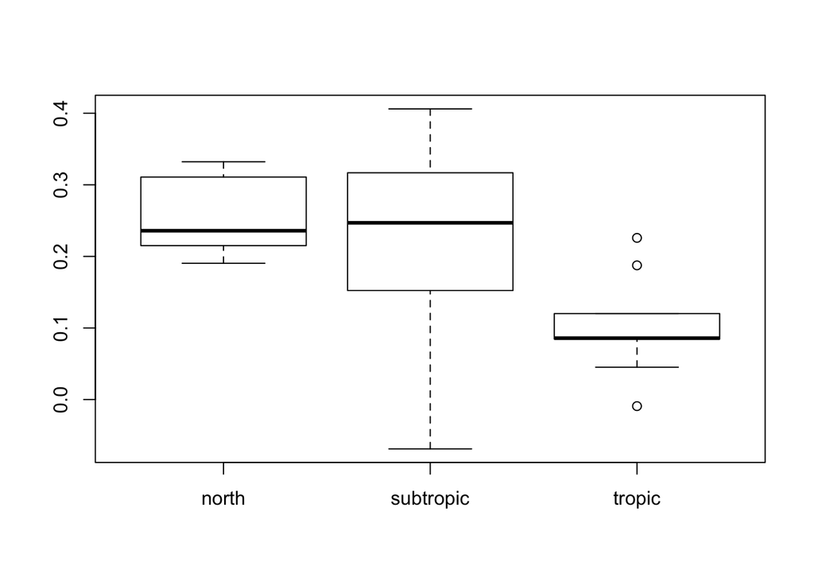

```
## $stats
##           [,1]        [,2]       [,3]
## [1,] 0.1903562 -0.06891235 0.04519539
## [2,] 0.2150966  0.15234462 0.08451254
## [3,] 0.2358351  0.24690812 0.08581220
## [4,] 0.3108596  0.31682052 0.12007359
## [5,] 0.3321824  0.40609773 0.12007359
##
## $n
## [1]  5 27  9
##
## $conf
##           [,1]      [,2]       [,3]
## [1,] 0.1681691 0.1968957 0.06708338
## [2,] 0.3035011 0.2969205 0.10454101
##
## $out
## [1]  0.187505472  0.225864708 -0.009185053
##
## $group
## [1] 3 3 3
##
## $names
## [1] "north"     "subtropic" "tropic"
```

```
##
##  F test to compare two variances
##
## data:  north$cooling and subtropic$cooling
## F = 0.497, num df = 4, denom df = 21, p-value = 0.5238
## alternative hypothesis: true ratio of variances is not equal to 1
## 95 percent confidence interval:
##  0.1430039 4.2473242
## sample estimates:
## ratio of variances
##          0.4969969
```

```
##
##  F test to compare two variances
##
## data:  north$cooling and tropic$cooling
## F = 0.2556, num df = 4, denom df = 13, p-value = 0.1979
## alternative hypothesis: true ratio of variances is not equal to 1
## 95 percent confidence interval:
##  0.06396834 2.22764832
## sample estimates:
## ratio of variances
##          0.2556109
```

```
##
##  F test to compare two variances
##
## data:  subtropic$cooling and tropic$cooling
## F = 0.5143, num df = 21, denom df = 13, p-value = 0.1692
## alternative hypothesis: true ratio of variances is not equal to 1
## 95 percent confidence interval:
##  0.1753982 1.3360701
## sample estimates:
## ratio of variances
##          0.5143109
```

```
##             Df Sum Sq Mean Sq F value Pr(>F)
## lat.name     2 0.1110 0.05552   4.137 0.0237 *
## Residuals   38 0.5099 0.01342
## ---
## Signif. codes:  0 '***' 0.001 '**' 0.01 '*' 0.05 '.' 0.1 ' ' 1
```

```
## $names
##  [1] "coefficients"  "residuals"     "effects"       "rank"
##  [5] "fitted.values" "assign"        "qr"            "df.residual"
##  [9] "contrasts"     "xlevels"       "call"          "terms"
## [13] "model"
##
## $class
## [1] "aov" "lm"
```

```
##       (Intercept) lat.namesubtropic    lat.nametropic
##         0.2568660        -0.0364511        -0.1532739
```

```
##   Tukey multiple comparisons of means
##     95% family-wise confidence level
##
## Fit: aov(formula = cooling ~ lat.name, data = data)
##
## $lat.name
##                        diff        lwr          upr     p adj
## subtropic-north  -0.0364511 -0.1740011  0.101098876 0.7955699
## tropic-north     -0.1532739 -0.3108572  0.004309366 0.0580275
## tropic-subtropic -0.1168228 -0.2255656 -0.008080027 0.0329006
```

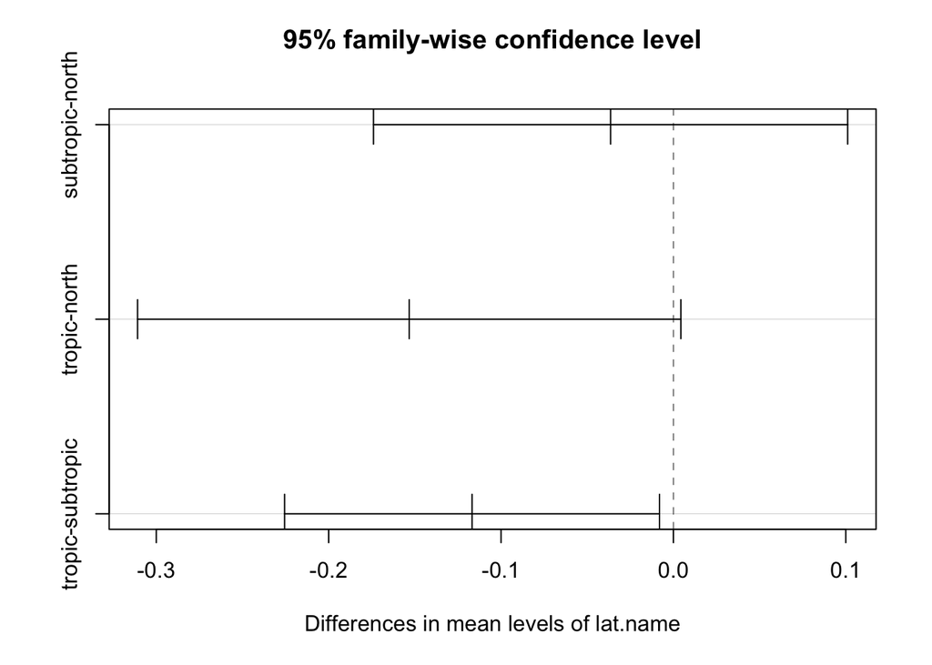

```
##
##  Two Sample t-test
##
## data:  tropic$cooling and north$cooling
## t = -2.8866, df = 17, p-value = 0.01025
## alternative hypothesis: true difference in means is not equal to 0
## 95 percent confidence interval:
##  -0.28823766 -0.04481042
## sample estimates:
##  mean of x  mean of y
## 0.09034196 0.25686599
```

```
##
##  Two Sample t-test
##
## data:  tropic$cooling and north$cooling
## t = -2.8866, df = 17, p-value = 0.005125
## alternative hypothesis: true difference in means is less than 0
## 95 percent confidence interval:
##         -Inf -0.06616748
## sample estimates:
##  mean of x  mean of y
## 0.09034196 0.25686599
```

```
##
##  Two Sample t-test
##
## data:  tropic$cooling and north$cooling
## t = -2.8866, df = 17, p-value = 0.9949
## alternative hypothesis: true difference in means is greater than 0
## 95 percent confidence interval:
##  -0.2668806        Inf
## sample estimates:
##  mean of x  mean of y
## 0.09034196 0.25686599
```

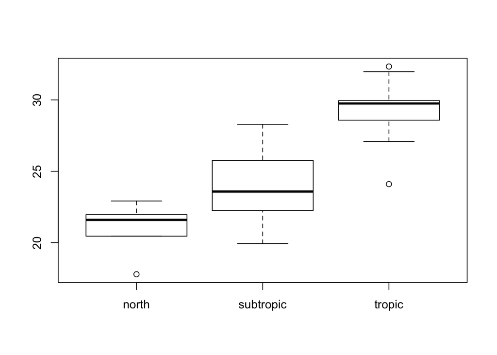

```
## $stats
##          [,1]     [,2]     [,3]
## [1,] 20.45704 19.92956 27.08390
## [2,] 20.45704 22.24809 28.57617
## [3,] 21.59908 23.58382 29.75004
## [4,] 21.97037 25.76548 29.95033
## [5,] 22.92103 28.29121 31.97710
##
## $n
## [1]  5 27  9
##
## $conf
##          [,1]     [,2]     [,3]
## [1,] 20.52976 22.51428 29.02632
## [2,] 22.66839 24.65336 30.47376
##
## $out
## [1] 17.79045 32.33636 24.10480
##
## $group
## [1] 1 3 3
##
## $names
## [1] "north"     "subtropic" "tropic"
```

```
##
##  F test to compare two variances
##
## data:  north$threshold.t and subtropic$threshold.t
## F = 1.0196, num df = 4, denom df = 21, p-value = 0.8399
## alternative hypothesis: true ratio of variances is not equal to 1
## 95 percent confidence interval:
##  0.2933857 8.7137787
## sample estimates:
## ratio of variances
##           1.019635
```

```
##
##  F test to compare two variances
##
## data:  north$threshold.t and tropic$threshold.t
## F = 0.2603, num df = 4, denom df = 13, p-value = 0.2037
## alternative hypothesis: true ratio of variances is not equal to 1
## 95 percent confidence interval:
##  0.06515067 2.26882221
## sample estimates:
## ratio of variances
##          0.2603354
```

```
##
##  F test to compare two variances
##
## data:  subtropic$threshold.t and tropic$threshold.t
## F = 0.2553, num df = 21, denom df = 13, p-value = 0.005477
## alternative hypothesis: true ratio of variances is not equal to 1
## 95 percent confidence interval:
##  0.08707387 0.66327247
## sample estimates:
## ratio of variances
##          0.2553221
```

```
##             Df Sum Sq Mean Sq F value   Pr(>F)
## lat.name     2  264.2  132.08   29.07 2.19e-08 ***
## Residuals   38  172.7    4.54
## ---
## Signif. codes:  0 '***' 0.001 '**' 0.01 '*' 0.05 '.' 0.1 ' ' 1
```

```
## $names
##  [1] "coefficients"  "residuals"     "effects"       "rank"
##  [5] "fitted.values" "assign"        "qr"            "df.residual"
##  [9] "contrasts"     "xlevels"       "call"          "terms"
## [13] "model"
##
## $class
## [1] "aov" "lm"
```

```
##       (Intercept) lat.namesubtropic    lat.nametropic
##         20.947595          3.055763          8.235006
```

```
##   Tukey multiple comparisons of means
##     95% family-wise confidence level
##
## Fit: aov(formula = threshold.t ~ lat.name, data = data)
##
## $lat.name
##                      diff       lwr       upr     p adj
## subtropic-north  3.055763 0.5248656  5.586659 0.0148361
## tropic-north     8.235006 5.3354993 11.134513 0.0000001
## tropic-subtropic 5.179243 3.1783937  7.180093 0.0000006
```

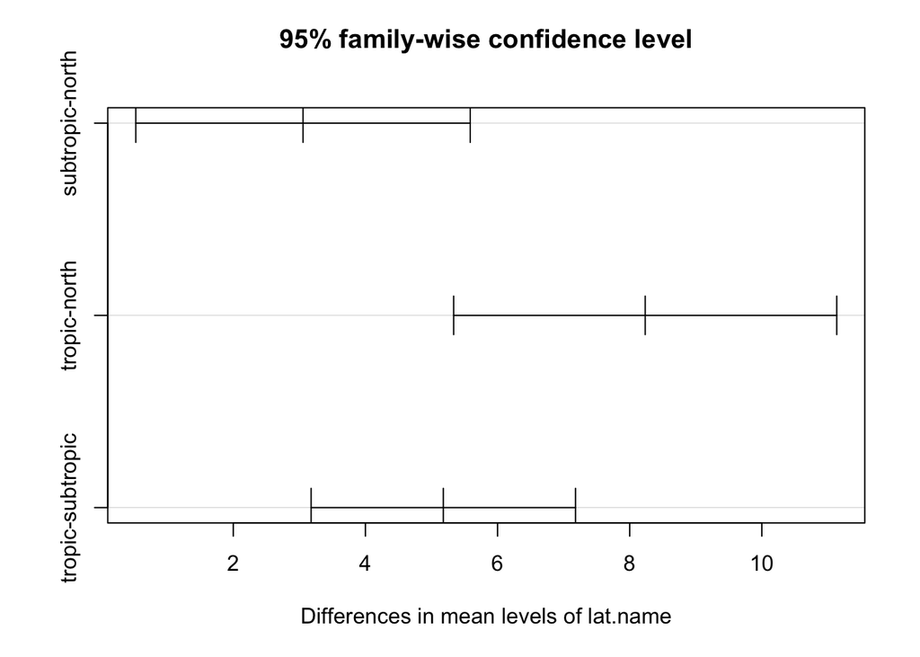

```
##
##  Two Sample t-test
##
## data:  subtropic$threshold.t and north$threshold.t
## t = 3.3939, df = 25, p-value = 0.002302
## alternative hypothesis: true difference in means is not equal to 0
## 95 percent confidence interval:
##  1.29380 5.28775
## sample estimates:
## mean of x mean of y
##  24.23837  20.94759
```

```
##
##  Two Sample t-test
##
## data:  subtropic$threshold.t and north$threshold.t
## t = 3.3939, df = 25, p-value = 0.9988
## alternative hypothesis: true difference in means is less than 0
## 95 percent confidence interval:
##      -Inf 4.947027
## sample estimates:
## mean of x mean of y
##  24.23837  20.94759
```

```
##
##  Two Sample t-test
##
## data:  subtropic$threshold.t and north$threshold.t
## t = 3.3939, df = 25, p-value = 0.001151
## alternative hypothesis: true difference in means is greater than 0
## 95 percent confidence interval:
##  1.634523      Inf
## sample estimates:
## mean of x mean of y
##  24.23837  20.94759
```

```
##
##  Two Sample t-test
##
## data:  tropic$threshold.t and north$threshold.t
## t = 3.2855, df = 17, p-value = 0.004364
## alternative hypothesis: true difference in means is not equal to 0
## 95 percent confidence interval:
##  2.152800 9.879142
## sample estimates:
## mean of x mean of y
##  26.96357  20.94759
```

```
##
##  Two Sample t-test
##
## data:  tropic$threshold.t and north$threshold.t
## t = 3.2855, df = 17, p-value = 0.9978
## alternative hypothesis: true difference in means is less than 0
## 95 percent confidence interval:
##      -Inf 9.201272
## sample estimates:
## mean of x mean of y
##  26.96357  20.94759
```

```
##
##  Two Sample t-test
##
## data:  tropic$threshold.t and north$threshold.t
## t = 3.2855, df = 17, p-value = 0.002182
## alternative hypothesis: true difference in means is greater than 0
## 95 percent confidence interval:
##  2.83067     Inf
## sample estimates:
## mean of x mean of y
##  26.96357  20.94759
```

```
##
##  Welch Two Sample t-test
##
## data:  tropic$threshold.t and subtropic$threshold.t
## t = 2.4456, df = 17.285, p-value = 0.02544
## alternative hypothesis: true difference in means is not equal to 0
## 95 percent confidence interval:
##  0.3770817 5.0733097
## sample estimates:
## mean of x mean of y
##  26.96357  24.23837
```

```
##
##  Welch Two Sample t-test
##
## data:  tropic$threshold.t and subtropic$threshold.t
## t = 2.4456, df = 17.285, p-value = 0.9873
## alternative hypothesis: true difference in means is less than 0
## 95 percent confidence interval:
##      -Inf 4.661882
## sample estimates:
## mean of x mean of y
##  26.96357  24.23837
```

```
##
##  Welch Two Sample t-test
##
## data:  tropic$threshold.t and subtropic$threshold.t
## t = 2.4456, df = 17.285, p-value = 0.01272
## alternative hypothesis: true difference in means is greater than 0
## 95 percent confidence interval:
##  0.7885098       Inf
## sample estimates:
## mean of x mean of y
##  26.96357  24.23837
```

Since cooling appliances are more often electric driven, we can assume that the cooling effect (right part of the V shape) is more significant. The significance in cooling effect is also shown in the figure that the V shape has a sharper slop in increasing interval than in decreasing interval. Therefore, we will focus on the cooling coefficient especially in our research. In order to have an insight about how differently demand-temperature coefficients are distributed according to different geographic groups, we transformed the scaled coefficients to per capita level in order to compare among each group and then used box plots to illustrate the relationship. The boxplot below shows the distribution of per capita scaled cooling coefficient, we can bring up hypotheses accordingly:

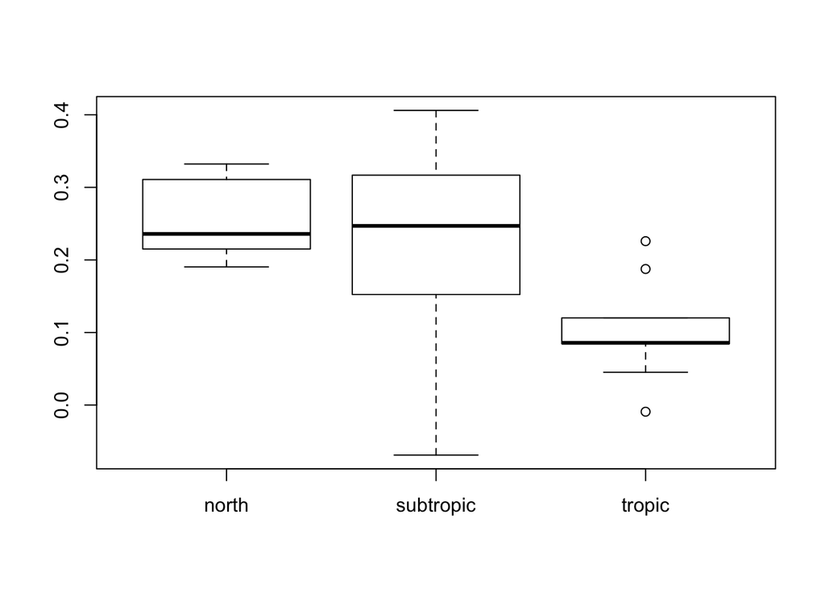

1. Cooling coefficient in the north is higher than sub-tropics; 2. Cooling coefficient in sub-tropics is higher than tropics; 3. Cooling coefficient in the north is higher than tropics;

Hypotheses on threshold temperatures can also be made according to the distribution of threshold temperatures:

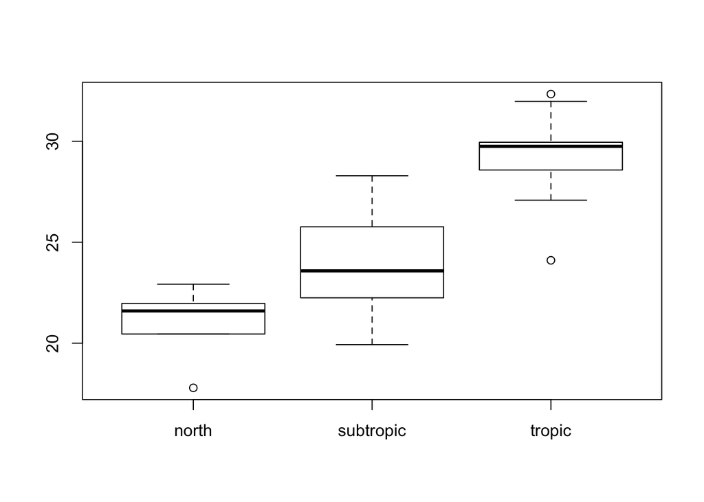

4. Threshold temperature in the north is lower than sub-tropics;
5. Threshold temperature in sub-tropics is lower than tropics;
6. Threshold temperature in the north is lower than tropics.

## Statistical Significance

### ANOVA test

We first used ANOVA test to see if the means of the three groups are equal. Use $\mu_n$,$\mu_s$,and $\mu_t$ to denote the means of the distribution in North, Subtropics and Tropics respectively. Then the null hypothesis in this test will be:

$\mu_{n} = \mu_{s} =\mu_{t}$

The output of the test results are as below. 1. Cooling coefficients:

```
##             Df Sum Sq Mean Sq F value Pr(>F)
## lat.name     2 0.1110 0.05552   4.137 0.0237 *
## Residuals   38 0.5099 0.01342
## ---
## Signif. codes:  0 '***' 0.001 '**' 0.01 '*' 0.05 '.' 0.1 ' ' 1
```

```
##   Tukey multiple comparisons of means
##     95% family-wise confidence level
##
## Fit: aov(formula = cooling ~ lat.name, data = data)
##
## $lat.name
##                        diff        lwr          upr     p adj
## subtropic-north  -0.0364511 -0.1740011  0.101098876 0.7955699
## tropic-north     -0.1532739 -0.3108572  0.004309366 0.0580275
## tropic-subtropic -0.1168228 -0.2255656 -0.008080027 0.0329006
```

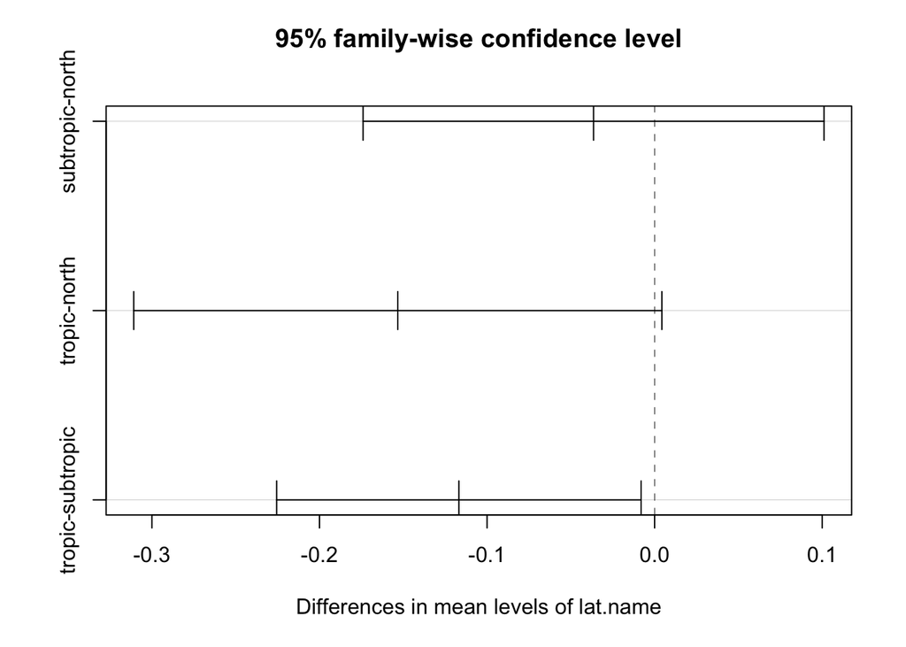

2. Threshold Temperatures:

```
##             Df Sum Sq Mean Sq F value   Pr(>F)
## lat.name     2  264.2  132.08   29.07 2.19e-08 ***
## Residuals   38  172.7    4.54
## ---
## Signif. codes:  0 '***' 0.001 '**' 0.01 '*' 0.05 '.' 0.1 ' ' 1
```

```
##   Tukey multiple comparisons of means
##     95% family-wise confidence level
##
## Fit: aov(formula = threshold.t ~ lat.name, data = data)
##
## $lat.name
##                      diff       lwr       upr     p adj
## subtropic-north  3.055763 0.5248656  5.586659 0.0148361
## tropic-north     8.235006 5.3354993 11.134513 0.0000001
## tropic-subtropic 5.179243 3.1783937  7.180093 0.0000006
```

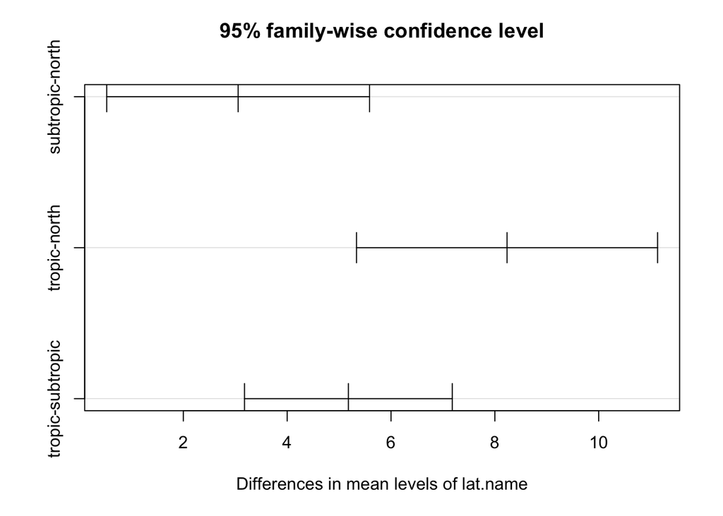

P-value of ANOVA test for threshold temperatures is satisfactorily samll – 2.19e-08, which allowed us to reject the null hypothesis at a very high confidence level. Also, from the results of Tukey’s test, we learned that all three two-pair groups have significant intra difference in threshold temperature means.

### T test

Based on the results from ANOVA test, we then move on to test the following hypotheses: H3. Cooling coefficient in the north is higher than tropics; H4. Threshold temperature in the north is lower than sub-tropics; H5. Threshold temperature in sub-tropics is lower than tropics; H6. Threshold temperature in the north is lower than tropics.

Take the test for H3 for example. The null hypothsis for this t test is “Cooling coefficient in the north is lower than tropics”. $H_{0}: \mu_{t} \geq \mu_{n}$

We first used F test to see if they have same variances. The results are as below. Since the p-value (0.1979) is large enough for us to not reject the null hypothesis, then we can say the two distributions have the same variance. Given the conclusion that the two distributions have same variances, we can conduct equal-variance t test and the results are given. Since the p-value = 0.005125, we can reject the null hypothesis at 99% confidence level and conclude that cooling coefficient in the north is higher than the cooling coefficient in the tropics.

```
##
##  F test to compare two variances
##
## data:  north$cooling and tropic$cooling
## F = 0.2556, num df = 4, denom df = 13, p-value = 0.1979
## alternative hypothesis: true ratio of variances is not equal to 1
## 95 percent confidence interval:
##  0.06396834 2.22764832
## sample estimates:
## ratio of variances
##          0.2556109
```

```
##
##  Two Sample t-test
##
## data:  tropic$cooling and north$cooling
## t = -2.8866, df = 17, p-value = 0.005125
## alternative hypothesis: true difference in means is less than 0
## 95 percent confidence interval:
##         -Inf -0.06616748
## sample estimates:
##  mean of x  mean of y
## 0.09034196 0.25686599
```

The similar test procedure is given to the rest of the hypothses. Here is a brief summary of the test results:

north-subtropics: equal variances (p-value = 0.8399); north < subtropics (p-value=0.001151) north-tropics: equal variances (p-value = 0.2037); north < tropics (p-value = 0.002182) subtropics-tropics: unequal variances (p-value = 0.005477); subtropics < tropics (p-value = 0.01272)

```
##
##  F test to compare two variances
##
## data:  north$threshold.t and subtropic$threshold.t
## F = 1.0196, num df = 4, denom df = 21, p-value = 0.8399
## alternative hypothesis: true ratio of variances is not equal to 1
## 95 percent confidence interval:
##  0.2933857 8.7137787
## sample estimates:
## ratio of variances
##           1.019635
```

```
##
##  Two Sample t-test
##
## data:  subtropic$threshold.t and north$threshold.t
## t = 3.3939, df = 25, p-value = 0.001151
## alternative hypothesis: true difference in means is greater than 0
## 95 percent confidence interval:
##  1.634523      Inf
## sample estimates:
## mean of x mean of y
##  24.23837  20.94759
```

```
##
##  F test to compare two variances
##
## data:  north$threshold.t and tropic$threshold.t
## F = 0.2603, num df = 4, denom df = 13, p-value = 0.2037
## alternative hypothesis: true ratio of variances is not equal to 1
## 95 percent confidence interval:
##  0.06515067 2.26882221
## sample estimates:
## ratio of variances
##          0.2603354
```

```
##
##  Two Sample t-test
##
## data:  tropic$threshold.t and north$threshold.t
## t = 3.2855, df = 17, p-value = 0.002182
## alternative hypothesis: true difference in means is greater than 0
## 95 percent confidence interval:
##  2.83067     Inf
## sample estimates:
## mean of x mean of y
##  26.96357  20.94759
```

```
##
##  F test to compare two variances
##
## data:  subtropic$threshold.t and tropic$threshold.t
## F = 0.2553, num df = 21, denom df = 13, p-value = 0.005477
## alternative hypothesis: true ratio of variances is not equal to 1
## 95 percent confidence interval:
##  0.08707387 0.66327247
## sample estimates:
## ratio of variances
##          0.2553221
```

```
##
##  Welch Two Sample t-test
##
## data:  tropic$threshold.t and subtropic$threshold.t
## t = 2.4456, df = 17.285, p-value = 0.01272
## alternative hypothesis: true difference in means is greater than 0
## 95 percent confidence interval:
##  0.7885098       Inf
## sample estimates:
## mean of x mean of y
##  26.96357  24.23837
```

Therefore, we successfully proved the 4 hypotheses (H3-H6) in the previous section that 1) cooling coefficient in the north is higher than tropics; 2) threshold temperature in the north is lower than subtropics, and the subtropics is lower than the tropics.

## Conclusions–Statistical Test

So far, the research managed to test the hypotheses on inter-group coefficient difference and threshold temperature with respect to latitude. Our results showed 1) even though the variances in coefficient donnot differ among the three groups, there is a significant difference in means between north and tropics that cooling coefficient in the north is bigger than the tropics; 2) the variances in threshod temperature only differ for subtropis-tropics group, and all three groups showed significant differences in means in intra-group comparison that “north < subtropis < tropics” is true. Explanation for the observations could be: since cities in the north experience more diverse seasons and have wider range of temperature change throughout the year, people are more sensitive to the hot weather; on the other hand, cities in the tropics have much more stable weather all year round, and the temperature don’t vary much during a day, therefore, people either are more used to the hot temperature and feel no need to use cooling appliances, or the temperature doesn’t vary much enough for the sensitivity to show. Other reasons could also be: cities in the north are richer and more urbanized than those in the tropics. This would be another theory to test in the next stage of our research.

## References

[1] Segal M., Shafer H., Mandel M.. Alpert P., & Balmor V. (1992). Climatic-related evaluations of the summer peak-hours’ electrical load in Israel. Journal of Applied Meteorology, 31, 1492-1498.  
[2] Christian Crowley., & Frederick L. Joutz. (2003). Hourly electricity loads: temperature elasticities and climate change. 23rd US Association of Energy Economics North American Conference.  
[3] Marcus J. Thatcher. (2007). Modeling changes to electricity demand load duration curves as a consequence of predicted climate change for Australia. Energy, 32, 1647-1659.  
[4] Bose, R.K., & M. Shukla. (1999). Elasticities of electricity demand in India. Energy Policy, 27(3), 137-146.  
[5] Tiwari, P. (2000). Architectural, demographic, and economic causes of electricity consumption in Bombay. Journal of Policy Modelling 22(1), 81–98.  
[6] Shonali Pachauri. (2004). An analysis of cross-sectional variations in total household energy requirements in India using micro survey data. Energy Policy, 32, 1723-1735.(S. Mirasgedis., Y. Sarafidis., E. Georgopoulou., D.P. Lalas., M. Moschovits., F. Karagiannis., D.  
[7] The World Bank. (2008). Residential Consumption of Electricity in India Documentation of Data and Methodology.  
[8] Pachauri, S. & Spreng, D. (2004) Energy Use and Energy Access in Relation to Poverty. Economic and Political Weekly, Vol. 39, No. 3 (Jan. 17-23, 2004), pp. 271-278  
[9] Gupta, (2012). Global Warming and Electricity Demand in the Rapidly Growing City of Delhi: A Semi-Parametric Coefficient Approach, Elsevier Energy  
[10] Gupta, (2014). The Effect Of Development on the Climate Sensitivity of Electricity in India, Discussion Papers in Economics, Indian Statistical Institute, Delhi, India  
[11] David J. Sailor., J, Ricardo Munoz. (1997). Sensitivity of electricity and natural gas consumption to climate in the USA—methodology and results for eight states. Energy, 22(10), 987-998.  
[12] Joshua D. Rhodes., Wesley J. Cole., Charles R. Upshaw., Thomas F. Edgar., & Michael E. Webber. Clustering analysis of residential electricity demand profiles. Applied Energy, 135, 461-471.  
[13] Heck, S. & Rogers, M. (2014). Resource Revolution (1st Edition). New York: Houghton Mifflin Harcourt  
[14] Smit,Remes, Manyika, Roxburgh, Restrepo (2011). Urban world: Mapping the economic power of cities. McKinsey Global Institue.  
[15] IEA World Energy Outlook 2014 Factsheet  
Austin Energy. (2006-2006). Residential Electricity burden: an investigation of American community survey data.  
[16] David J. Sailor., J, Ricardo Munoz. (1997). Sensitivity of electricity and natural gas consumption to climate in the USA—methodology and results for eight states. Energy, 22(10), 987-998.  
[17] Energy Information Administration. Electricity Power Monthly. http://www.eia.gov/ electricity/monthly/index.cfm  
[18] Huang, Y. J., Ritschard, R., Bull, J., Chang, L. (1986), Climatic indicators for estimating residential heating and cooling loads. Lawrence Berkeley Laboratory, Report LBL-21 I01, Berkeley, CA.  
[19] Joshua D. Rhodes., Wesley J. Cole., Charles R. Upshaw., Thomas F. Edgar., & Michael E. Webber. Clustering analysis of residential electricity demand profiles. Applied Energy, 135, 461-471.  
[20] Li, X., Sailor, D.J.,(1995). Electricity use sensitivity to climate and climate change. World Resource, 7(3), 334-346.  
[21] Massimo Filippini., & Shonali Pachauri. (2004). Elasticities of electricity demand in urban Indian households. Energy Policy, 32, 429-436.  
[22] Sailor DJ. (2001). Relating residential and commercial sector electricity loads to climate —evaluating state level sensitivities and vulnerabilities. Energy, 26, 645-657.  
[23] Scott, M.J., Wrech, L.E., Hadley, D.L. (1994). Effects of Climate Change on Commercial Building Energy Demand. Energy Sources, 16, 317-332.  
[24] S. Mirasgedis., Y. Sarafidis., E. Georgopoulou., D.P. Lalas., M. Moschovits., F. Karagiannis., D. Papakonstantinou. (2006). Models for mid-term electricity demand forecasting incorporating weather influences. Energy, 31: 208–227.  
[25] U.S. Census Bureau. (1995-present). American Community Survey. http://www.census.gov/acs/  
[27] U.S. Census Bureau. Working at home is on the rise. http://www.census.gov/newsroom/releases/pdf/home_based_workers_us_infographic.pdf